# 1. Daniel Bernoulli

Let $y_1, ..., y_n|θ ∼ Bern(θ)$, and assume that you have obtained a sample with $f = 35$ failures in $n = 78$ trials. Assume a $Beta(α_0, β_0)$ prior for $θ$ and let $α_0 = β_0 = 7$.

## 1.1

**Draw 10000 random values (nDraws = 10000) from the posterior $θ|y ∼ Beta(α_0+s, β_0 + f )$, where $y = (y_1, . . . , y_n)$, and verify graphically that the posterior mean $E[θ|y]$ and standard deviation $SD[θ|y]$ converges to the true values as the number of random draws grows large. [Hint: use rbeta() to draw random values and make graphs of the sample means and standard deviations of θ as a function of the accumulating number of drawn values].**

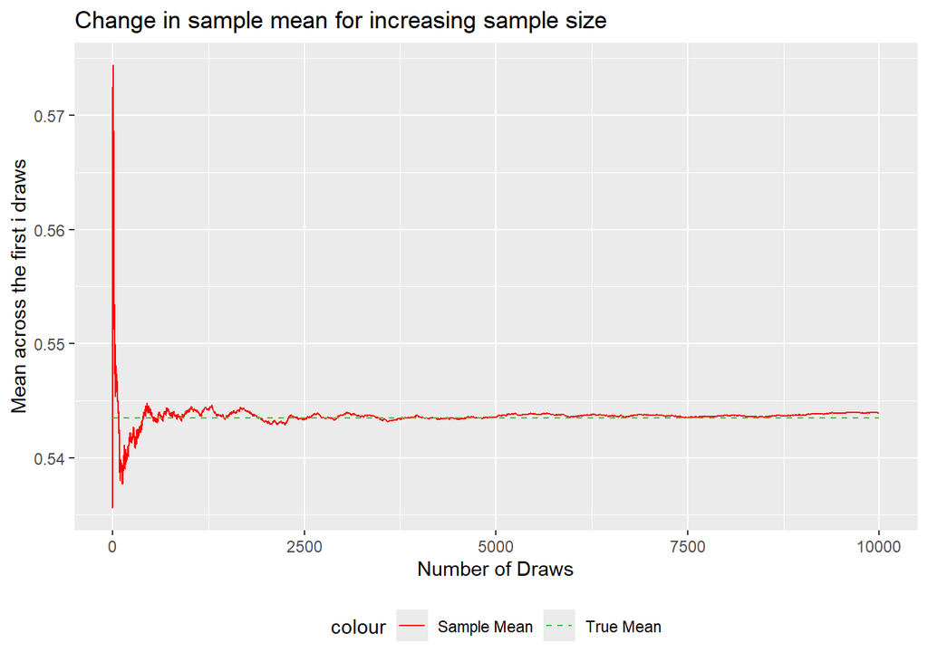

```r
library(ggplot2)
n <- 78
f <- 35
s <- n - f
alpha <- 7
beta <- 7
drawsize <- 10000

posterior_sample <- function(n, alpha, beta, f, s){
  return(rbeta(n, alpha + s, beta + f))
}

n_draws <- posterior_sample(drawsize, alpha, beta, f, s)
n_means <- numeric(drawsize)
n_sds <- numeric(drawsize)

for(i in 1:drawsize){
  n_means[[i]] <- mean(n_draws[1:i])
  n_sds[[i]] <- sd(n_draws[1:i])
}

n_sds[[1]] <- 0

a <- alpha + s
b <- beta + f

# Calculate mean and standard deviation according to beta distribution
true_mean <- a / (a + b)
true_sd <- sqrt((a * b) / ((a + b)^2 * (a + b + 1)))

# Create a data frame for horizontal line to allow for color mapping
hline_data <- data.frame(x = c(1, 10000), y = true_mean)

p <- ggplot() +
  aes(x = (1:10000), y = n_means, color = "Sample Mean") +
  geom_line() +
  xlab("Number of Draws") +
  ylab("Mean across the first i draws") +
  ggtitle("Change in sample mean for increasing sample size") +
  geom_line(data = hline_data, aes(x = x, y = y, color = "True Mean"), linetype = "dashed") +
  scale_color_manual(values = c("Sample Mean" = "red", "True Mean" = "limegreen")) +
  theme(legend.position = "bottom")

print(p)
```

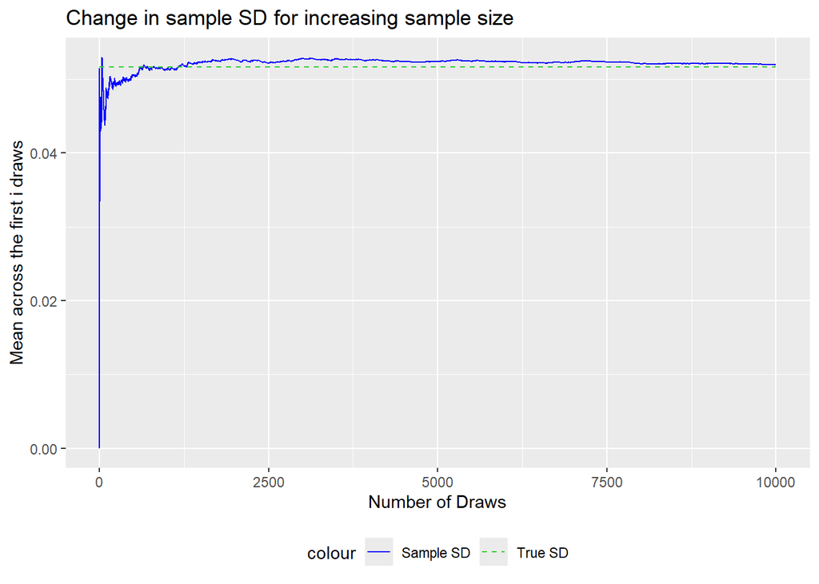

```r
hline_data <- data.frame(x = c(1, 10000), y = true_sd)
p <- ggplot() +
  aes(x = (1:10000), y = n_sds, color = "Sample SD") +
  geom_line() +
  xlab("Number of Draws") +
  ylab("Mean across the first i draws") +
  ggtitle("Change in sample SD for increasing sample size") +
  geom_line(data = hline_data, aes(x = x, y = y, color = "True SD"), linetype = "dashed") +
  scale_color_manual(values = c("Sample SD" = "blue", "True SD" = "limegreen")) +
  theme(legend.position = "bottom")

print(p)
```